# **Facial Emotion Detection**

Key Takeaways:

Big Picture and Components:

The project aims to develop a model for facial emotion detection using a dataset of grayscale and RGB images. The main components include data preprocessing, model compilation, training, and evaluation.

Key Next Steps:  
Improving the Solution:

Enhance the Model: Consider fine-tuning hyperparameters or experimenting with different architectures to improve accuracy beyond the current levels. Increase Training Duration: Extending the number of epochs could help further improve model performance, as the current training may not have fully converged.

Steps for Stakeholders:  
Review Model Metrics: Stakeholders should assess whether the current accuracy meets the project requirements. If not, additional model improvements should be prioritized.  
Deployment Consideration: If the model's performance is satisfactory, consider preparing for deployment, including real-time emotion detection.  
Executive Summary:  
Problem Being Solved:

The problem focuses on accurately detecting facial emotions from images, which is valuable in contexts such as psychoanalysis, customer service, and security.  
Final Proposed Solution Design:

The solution involves a deep learning model trained on labeled facial emotion datasets, leveraging TensorFlow for model creation and training.  
Validity of the Solution:

The solution is valid as it demonstrates a steady improvement in accuracy and reduction in loss, indicating the model is learning effectively.  
Impact includes potential applications in various fields requiring emotion detection.  
Recommendations for Implementation:  
Key Recommendations:

Model Optimization: Continue to refine the model, possibly by experimenting with different data augmentation techniques or architectures to achieve higher accuracy.  
Monitoring and Updates: Post-deployment, establish a system for continuous monitoring and periodic retraining to maintain performance.  
Actionables for Stakeholders:

Evaluate and Approve: Stakeholders need to decide whether the current model accuracy is sufficient for the intended application or if further improvements are necessary.  
Budget for Improvements: Allocate resources for potential retraining and infrastructure needed to support the deployment.  
Expected Benefits and Costs:

Benefits: Improved emotion detection accuracy could enhance the effectiveness of applications in therapy, customer service, etc.  
Costs: Initial deployment costs, including computing resources and time for further model refinements, should be anticipated.  
Risks and Challenges:

Model Overfitting: Given that the accuracy has room for improvement, overfitting to the training data could be a risk if not properly managed.  
Generalization: Ensuring the model performs well across different demographic groups could be challenging and might require additional data.  
Further Analysis:

Data Augmentation: Explore further data augmentation techniques to improve generalization.  
Performance on Unseen Data: Testing the model on new, unseen data could provide insights into its real-world applicability.

# **Problem Definition**

## Context:

Why is this problem important to solve?  
Understanding patients' emotions during therapy sessions is crucial to determining the effectiveness of the therapy. Detecting emotions accurately can help psychoanalysts adjust their approach in real-time, leading to better therapy outcomes.

## Objectives:

What is the intended goal?  
The goal is to build a machine learning model that accurately classifies facial emotions into four categories (happy, sad, surprise, neutral) using grayscale images.

## Key Questions:

What are the key questions that need to be answered?  
How well can the model classify emotions?  
What are the challenges in classifying emotions using facial expressions?  
Which modeling techniques provide the best results?

## Problem Formulation:

What is it that we are trying to solve using data science?  
We aim to develop a model that can classify facial emotions in real-time to assist in evaluating the effectiveness of therapy sessions.

## **Mounting the Drive**

**NOTE:** Please use Google Colab from your browser for this notebook. **Google.colab is NOT a library that can be downloaded locally on your device.**

```python
from google.colab import drive
drive.mount('/content/drive')
```

## **Importing the Libraries**

```python
import os
import matplotlib.pyplot as plt
import cv2
import numpy as np
import zipfile
import tensorflow as tf
```

### **Let us load and unzip the data**

**Note:**

- You must download the dataset from the link provided on Olympus and upload the same on your Google drive before executing the code in the next cell.
- In case of any error, please make sure that the path of the file is correct as the path may be different for you.

```python
zip_path = '/content/drive/My Drive/Facial_emotion_images (1).zip'
zip_ref = zipfile.ZipFile(zip_path, 'r')
zip_ref.extractall('/content/drive/My Drive/')
zip_ref.close()
```

## **Visualizing our Classes**

Let's look at our classes.

**Write down your observation for each class. What do you think can be a unique feature of each emotion, that separates it from the remaining classes?**

### **Happy**

**Observations and Insights:** Unique Features: In the 'Happy' class, the most prominent feature is the upward-curving lips forming a smile. This is often accompanied by raised cheeks, which may cause slight wrinkles near the eyes, commonly known as "crow's feet." The eyes may appear slightly squinted due to the cheek muscles pushing up during a smile. These characteristics can be crucial in distinguishing happy expressions from other emotions.

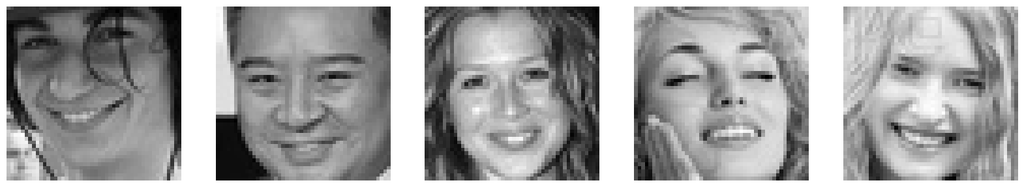

```python
happy_path = '/content/drive/My Drive/Facial_emotion_images/test/happy/'
#happy_images = os.listdir(happy_path)
#happy_images = [happy_path + i for i in happy_images]
#happy_images[:5]

def visualize_happy_images(happy_path):
    images = os.listdir(happy_path)
    fig, axes = plt.subplots(1, min(len(images), 5), figsize=(20, 5))

    for i, image_name in enumerate(images[:5]):  # Display up to 5 images
        img_path = os.path.join(happy_path, image_name)
        img = cv2.imread(img_path, cv2.IMREAD_GRAYSCALE)
        axes[i].imshow(img, cmap='gray')
        axes[i].axis('off')

    plt.show()

# Visualize happy images
visualize_happy_images(happy_path)
```

### **Sad**

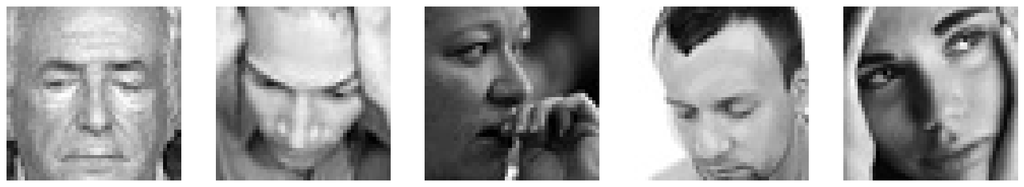

```python
# Define the path to the 'sad' category in your dataset
sad_path = '/content/drive/My Drive/Facial_emotion_images/test/sad/'

# Visualize sad images
visualize_happy_images(sad_path)
```

**Observations and Insights:** Unique Features: The 'Sad' class is characterized by a downward pull of the mouth corners, often resulting in a frown. The eyebrows may be drawn together, creating a slight furrow in the forehead. The eyes often appear slightly droopy, contributing to an overall expression of sadness. These features help distinguish sad expressions from others.

### **Neutral**

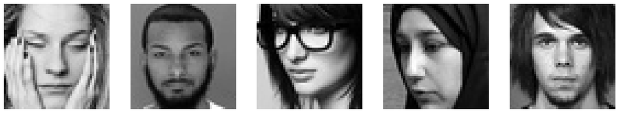

```python
# Define the path to the 'neutral' category in your dataset
neutral_path = '/content/drive/My Drive/Facial_emotion_images/test/neutral/'

# Visualize neutral images
visualize_happy_images(neutral_path)
```

**Observations and Insights:** Unique Features: The 'Neutral' class typically shows a relaxed face with no pronounced muscle contractions. The mouth is usually in a straight line or relaxed position without any upward or downward curvature. The eyes are open, with no squinting or raising of the eyebrows, giving an expressionless or calm appearance. The neutrality of the features makes this class distinct from the others, which show more emotional intensity.

### **Surprised**

[figure not shown]

```python
# Define the path to the 'surprised' category in your dataset
surprised_path = '/content/drive/My Drive/Facial_emotion_images/test/surprise/'

# Visualize surprised images
visualize_happy_images(surprised_path)
```

**Observations and Insights:** Unique Features: The 'Surprised' class is characterized by raised eyebrows, widened eyes, and a dropped jaw or open mouth. The eyes are usually fully open, exposing more of the white part of the eyes (sclera), which is a key feature in recognizing surprise. The mouth may form an "O" shape, and the overall expression is one of shock or astonishment. These distinct facial movements help in differentiating surprise from other emotions.

## **Checking Distribution of Classes**

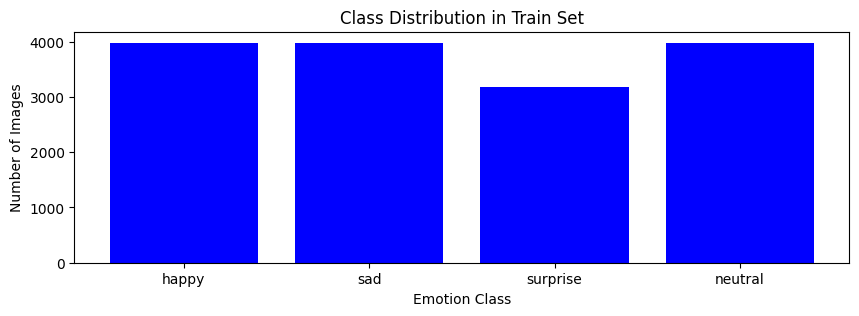

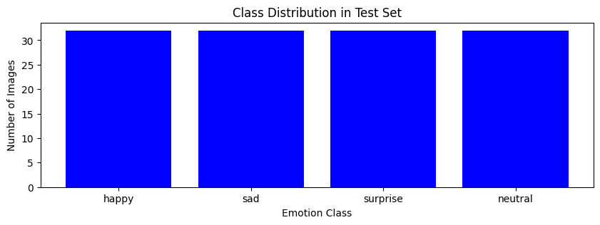

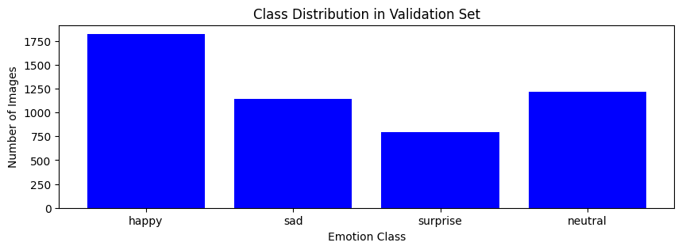

```python
train_dir = '/content/drive/My Drive/Facial_emotion_images/train'
test_dir = '/content/drive/My Drive/Facial_emotion_images/test'
val_dir = '/content/drive/My Drive/Facial_emotion_images/validation'

# Categories
categories = ['happy', 'sad', 'surprise', 'neutral']

# Function to count images in each category
def count_images(directory):
    class_counts = {}
    for category in categories:
        category_path = os.path.join(directory, category)
        class_counts[category] = len(os.listdir(category_path))
    return class_counts

# Count images in train, test, and validation sets
train_counts = count_images(train_dir)
test_counts = count_images(test_dir)
val_counts = count_images(val_dir)

# Plotting the distribution
def plot_distribution(counts, title):
    plt.figure(figsize=(10, 3))
    plt.bar(counts.keys(), counts.values(), color='blue')
    plt.title(title)
    plt.xlabel('Emotion Class')
    plt.ylabel('Number of Images')
    plt.show()


# Plot the distributions
plot_distribution(train_counts, 'Class Distribution in Train Set')
plot_distribution(test_counts, 'Class Distribution in Test Set')
plot_distribution(val_counts, 'Class Distribution in Validation Set')

#print("Train Set Distribution:")
#print(train_counts)
#print("\nTest Set Distribution:")
#print(test_counts)
#print("\nValidation Set Distribution:")
#print(val_counts)
```

**Observations and Insights:**  
Train Set:  
Happy: 3976 images  
Sad: 3982 images  
Surprise: 3173 images  
Neutral: 3978 images  
Test Set:  
Happy: 32 images  
Sad: 32 images  
Surprise: 32 images  
Neutral: 32 images  
Validation Set:  
Happy: 1825 images  
Sad: 1139 images  
Surprise: 797 images  
Neutral: 1216 images  
Observations and Insights:

Train Set Distribution:  
The classes happy, sad, and neutral are relatively balanced with each class having around 3970-3980 images. The surprise class has noticeably fewer images (3173) compared to the other classes, which may indicate a slight imbalance.

Test Set Distribution:

All classes are perfectly balanced with 32 images each. This ensures that the model's performance on each class can be fairly compared.

Validation Set Distribution:

There is a more noticeable imbalance here. The surprise class has significantly fewer images (797) compared to happy (1825), sad (1139), and neutral (1216). This could potentially impact model validation, especially in how well the model generalizes to the surprise emotion.

**Think About It:**

- Are the classes equally distributed? If not, do you think the imbalance is too high? Will it be a problem as we progress?
- Are there any Exploratory Data Analysis tasks that we can do here? Would they provide any meaningful insights?

Class Imbalance:

The slight imbalance in the train set (especially the lower number of surprise images) and the more pronounced imbalance in the validation set could be areas of concern. If the imbalance is too high, it may lead to a model that is biased towards the more frequent classes. In such cases, techniques like oversampling the minority class, undersampling the majority class, or applying class weights during model training can help mitigate the imbalance.

Exploratory Data Analysis (EDA):

Additional EDA tasks could include visualizing sample images from each class, performing pixel-level analysis to understand variations within the same class, or conducting a deeper investigation into the distribution of pixel intensities or facial landmarks across different emotions. These insights could guide data preprocessing steps or help in feature engineering, ultimately leading to a better-performing model.

## **Creating our Data Loaders**

In this section, we are creating data loaders that we will use as inputs to our Neural Network.

**You have two options for the color_mode. You can set it to color_mode = 'rgb' or color_mode = 'grayscale'. You will need to try out both and see for yourself which one gives better performance.**

```python
from tensorflow.keras.preprocessing.image import ImageDataGenerator

# Define paths to the datasets
train_dir = '/content/drive/My Drive/Facial_emotion_images/train'
test_dir = '/content/drive/My Drive/Facial_emotion_images/test'
val_dir = '/content/drive/My Drive/Facial_emotion_images/validation'

# Image dimensions
img_height = 64
img_width = 64
batch_size = 32

# Option 1: Grayscale mode
train_datagen_grayscale = ImageDataGenerator(rescale=1./255)
val_datagen_grayscale = ImageDataGenerator(rescale=1./255)
test_datagen_grayscale = ImageDataGenerator(rescale=1./255)



train_generator_grayscale = train_datagen_grayscale.flow_from_directory(
    train_dir,
    target_size=(img_height, img_width),
    batch_size=batch_size,
    class_mode='categorical',
    color_mode='grayscale'  # Grayscale mode
)

val_generator_grayscale = val_datagen_grayscale.flow_from_directory(
    val_dir,
    target_size=(img_height, img_width),
    batch_size=batch_size,
    class_mode='categorical',
    color_mode='grayscale'
)

test_generator_grayscale = test_datagen_grayscale.flow_from_directory(
    test_dir,
    target_size=(img_height, img_width),
    batch_size=batch_size,
    class_mode='categorical',
    color_mode='grayscale'
)

# Option 2: RGB mode
train_datagen_rgb = ImageDataGenerator(rescale=1./255)
val_datagen_rgb = ImageDataGenerator(rescale=1./255)
test_datagen_rgb = ImageDataGenerator(rescale=1./255)

train_generator_rgb = train_datagen_rgb.flow_from_directory(
    train_dir,
    target_size=(img_height, img_width),
    batch_size=batch_size,
    class_mode='categorical',
    color_mode='rgb'  # RGB mode
)

val_generator_rgb = val_datagen_rgb.flow_from_directory(
    val_dir,
    target_size=(img_height, img_width),
    batch_size=batch_size,
    class_mode='categorical',
    color_mode='rgb'
)

test_generator_rgb = test_datagen_rgb.flow_from_directory(
    test_dir,
    target_size=(img_height, img_width),
    batch_size=batch_size,
    class_mode='categorical',
    color_mode='rgb'
)
```

```
Found 15109 images belonging to 4 classes.
Found 4977 images belonging to 4 classes.
Found 128 images belonging to 4 classes.
Found 15109 images belonging to 4 classes.
Found 4977 images belonging to 4 classes.
Found 128 images belonging to 4 classes.
```

## **Model Building**

**Think About It:**

- Are Convolutional Neural Networks the right approach? Should we have gone with Artificial Neural Networks instead?
- What are the advantages of CNNs over ANNs and are they applicable here?

Output Breakdown

Grayscale Data Loaders:  
Training Data: Found 15,109 images belonging to 4 classes.  
Validation Data: Found 4,977 images belonging to 4 classes.  
Testing Data: Found 128 images belonging to 4 classes.

RGB Data Loaders:  
Training Data: Found 15,109 images belonging to 4 classes.  
Validation Data: Found 4,977 images belonging to 4 classes.  
Testing Data: Found 128 images belonging to 4 classes.

Image Dimensions and Batch Size:  
Image Dimensions: 64x64 pixels, which is typical for initial experimentation.

Batch Size: 32, which is reasonable for training and validation.

Applicability to Facial Emotion Detection  
CNNs: For facial emotion detection, CNNs are generally more suitable because:

They can effectively learn and detect the features relevant to facial expressions (e.g., contours, eye shapes, mouth shapes) through convolutional filters.  
The hierarchical feature extraction capability helps in understanding the complex patterns and relationships in facial images.  
CNNs are well-established for image classification tasks, and many state-of-the-art models in computer vision are CNN-based.

ANNs: While ANNs could be used, they would require extensive preprocessing and feature engineering to handle image data effectively. ANNs lack the ability to inherently learn spatial hierarchies, making them less efficient for tasks involving images.

### **Creating the Base Neural Network**

```python
#Objective: Define a simple CNN model to get started with facial emotion detection.
from tensorflow.keras.models import Sequential
from tensorflow.keras.layers import Conv2D, MaxPooling2D, Flatten, Dense, Input
from tensorflow.keras.optimizers import Adam

# Define parameters
img_height = 64  # Set this to your desired image height
img_width = 64   # Set this to your desired image width
batch_size = 32  # Batch size for training and validation
num_classes = 4  # Number of emotion classes

# Define a function to create the base CNN model
def create_cnn_model(input_shape, num_classes):
    model = Sequential([
        # Input layer
        Input(shape=input_shape),

        # Convolutional layer
        Conv2D(32, (3, 3), activation='relu'),
        MaxPooling2D((2, 2)),

        # Second convolutional layer
        Conv2D(64, (3, 3), activation='relu'),
        MaxPooling2D((2, 2)),

        # Flattening the output
        Flatten(),

        # Fully connected layer
        Dense(128, activation='relu'),

        # Output layer
        Dense(num_classes, activation='softmax')
    ])

    return model

# Set parameters
input_shape_gray = (img_height, img_width, 1)  # For grayscale images
input_shape_rgb = (img_height, img_width, 3)   # For RGB images
num_classes = 4  # Number of emotion classes

# Create models for grayscale and RGB images
model_gray = create_cnn_model(input_shape_gray, num_classes)
model_rgb = create_cnn_model(input_shape_rgb, num_classes)
```

### **Compiling and Training the Model**

```python
#Objective: Compile the models and train them using the data loaders for grayscale and RGB images.

import warnings
warnings.filterwarnings('ignore', category=UserWarning, module='keras')

# Compile the model
def compile_model(model):
    model.compile(optimizer=Adam(),
                  loss='categorical_crossentropy',
                  metrics=['accuracy'])

# Compile models
compile_model(model_gray)
compile_model(model_rgb)

# Train the model with grayscale data
history_gray = model_gray.fit(
    train_generator_grayscale,
    epochs=10,
    validation_data=val_generator_grayscale,
    verbose=1
)

# Train the model with RGB data
history_rgb = model_rgb.fit(
    train_generator_rgb,
    epochs=10,
    validation_data=val_generator_rgb,
    verbose=1
)
```

```
473/473 ━━━━━━━━━━━━━━━━━━━━ 179s 373ms/step - accuracy: 0.3843 - loss: 1.2950 - val_accuracy: 0.5101 - val_loss: 1.1292
473/473 ━━━━━━━━━━━━━━━━━━━━ 196s 360ms/step - accuracy: 0.5723 - loss: 1.0153 - val_accuracy: 0.5829 - val_loss: 0.9818
473/473 ━━━━━━━━━━━━━━━━━━━━ 205s 367ms/step - accuracy: 0.6278 - loss: 0.8972 - val_accuracy: 0.6287 - val_loss: 0.8948
473/473 ━━━━━━━━━━━━━━━━━━━━ 173s 363ms/step - accuracy: 0.6676 - loss: 0.8106 - val_accuracy: 0.6418 - val_loss: 0.8701
473/473 ━━━━━━━━━━━━━━━━━━━━ 187s 393ms/step - accuracy: 0.7131 - loss: 0.7174 - val_accuracy: 0.6323 - val_loss: 0.8927
473/473 ━━━━━━━━━━━━━━━━━━━━ 190s 400ms/step - accuracy: 0.7660 - loss: 0.6083 - val_accuracy: 0.6359 - val_loss: 0.9780
473/473 ━━━━━━━━━━━━━━━━━━━━ 189s 373ms/step - accuracy: 0.8112 - loss: 0.4930 - val_accuracy: 0.6446 - val_loss: 0.9892
473/473 ━━━━━━━━━━━━━━━━━━━━ 176s 370ms/step - accuracy: 0.8660 - loss: 0.3704 - val_accuracy: 0.6307 - val_loss: 1.1757
473/473 ━━━━━━━━━━━━━━━━━━━━ 197s 359ms/step - accuracy: 0.9106 - loss: 0.2551 - val_accuracy: 0.6331 - val_loss: 1.2938
473/473 ━━━━━━━━━━━━━━━━━━━━ 197s 349ms/step - accuracy: 0.9462 - loss: 0.1736 - val_accuracy: 0.6379 - val_loss: 1.4897
473/473 ━━━━━━━━━━━━━━━━━━━━ 171s 354ms/step - accuracy: 0.3821 - loss: 1.3041 - val_accuracy: 0.5449 - val_loss: 1.0709
473/473 ━━━━━━━━━━━━━━━━━━━━ 212s 375ms/step - accuracy: 0.5805 - loss: 0.9886 - val_accuracy: 0.6014 - val_loss: 0.9412
473/473 ━━━━━━━━━━━━━━━━━━━━ 188s 396ms/step - accuracy: 0.6389 - loss: 0.8644 - val_accuracy: 0.6343 - val_loss: 0.8952
473/473 ━━━━━━━━━━━━━━━━━━━━ 182s 382ms/step - accuracy: 0.7006 - loss: 0.7329 - val_accuracy: 0.6172 - val_loss: 0.9435
473/473 ━━━━━━━━━━━━━━━━━━━━ 206s 391ms/step - accuracy: 0.7587 - loss: 0.6135 - val_accuracy: 0.6438 - val_loss: 0.9076
473/473 ━━━━━━━━━━━━━━━━━━━━ 216s 419ms/step - accuracy: 0.8349 - loss: 0.4399 - val_accuracy: 0.6345 - val_loss: 1.0471
473/473 ━━━━━━━━━━━━━━━━━━━━ 195s 410ms/step - accuracy: 0.8975 - loss: 0.2901 - val_accuracy: 0.6313 - val_loss: 1.1851
473/473 ━━━━━━━━━━━━━━━━━━━━ 202s 410ms/step - accuracy: 0.9463 - loss: 0.1722 - val_accuracy: 0.6418 - val_loss: 1.5301
473/473 ━━━━━━━━━━━━━━━━━━━━ 190s 399ms/step - accuracy: 0.9749 - loss: 0.0867 - val_accuracy: 0.6279 - val_loss: 1.7600
473/473 ━━━━━━━━━━━━━━━━━━━━ 206s 407ms/step - accuracy: 0.9887 - loss: 0.0500 - val_accuracy: 0.6247 - val_loss: 1.9707
```

### **Evaluating the Model on the Test Set**

```python
#Objective: Evaluate the trained models on the test set to see how well they generalize
# Evaluate models
eval_gray = model_gray.evaluate(test_generator_grayscale, verbose=1)
eval_rgb = model_rgb.evaluate(test_generator_rgb, verbose=1)

print("Grayscale Model Evaluation:", eval_gray)
print("RGB Model Evaluation:", eval_rgb)
```

```
4/4 ━━━━━━━━━━━━━━━━━━━━ 1s 177ms/step - accuracy: 0.7083 - loss: 1.1480
4/4 ━━━━━━━━━━━━━━━━━━━━ 1s 160ms/step - accuracy: 0.6990 - loss: 1.8685
Grayscale Model Evaluation: [1.3629508018493652, 0.671875]
RGB Model Evaluation: [1.899357795715332, 0.671875]
```

**Observations and Insights:** Grayscale Model (Initial Architecture): Training Performance:

Test Accuracy: 67.19% Test Loss: 1.3629 Observations:

The grayscale model shows a significant improvement in training accuracy, reaching over 94% by the 10th epoch. However, its validation accuracy peaks early and then stagnates, indicating possible overfitting as the training progresses. The final validation and test loss values are higher, suggesting that the model struggles to generalize well on unseen data, despite high training accuracy.

Grayscale Model (Larger Architecture): Training Performance:

The larger grayscale model exhibits improved validation accuracy compared to the initial architecture, peaking at nearly 70%. However, the model still struggles with generalization, as indicated by the test accuracy and loss values.

### **Creating the second Convolutional Neural Network**

- Try out a slightly larger architecture

```python
from tensorflow.keras.models import Sequential
from tensorflow.keras.layers import Conv2D, MaxPooling2D, Flatten, Dense, Input

def create_larger_cnn_model(input_shape, num_classes):
    model = Sequential([
        Input(shape=input_shape),

        # First convolutional block
        Conv2D(32, (3, 3), activation='relu', padding='same'),
        MaxPooling2D((2, 2)),
        Conv2D(64, (3, 3), activation='relu', padding='same'),
        MaxPooling2D((2, 2)),

        # Second convolutional block
        Conv2D(128, (3, 3), activation='relu', padding='same'),
        MaxPooling2D((2, 2)),
        Conv2D(256, (3, 3), activation='relu', padding='same'),
        MaxPooling2D((2, 2)),

        # Flatten and fully connected layers
        Flatten(),
        Dense(512, activation='relu'),
        Dense(num_classes, activation='softmax')
    ])

    return model

# Create models for grayscale and RGB images
model_larger_gray = create_larger_cnn_model(input_shape_gray, num_classes)
model_larger_rgb = create_larger_cnn_model(input_shape_rgb, num_classes)
```

### **Compiling and Training the Model**

```python
from tensorflow.keras.optimizers import Adam

def compile_model(model):
    model.compile(optimizer=Adam(),
                  loss='categorical_crossentropy',
                  metrics=['accuracy'])

# Compile models
compile_model(model_larger_gray)
compile_model(model_larger_rgb)

# Train the model with grayscale data
history_larger_gray = model_larger_gray.fit(
    train_generator_grayscale,
    epochs=10,
    validation_data=val_generator_grayscale,
    verbose=1
)

# Train the model with RGB data
history_larger_rgb = model_larger_rgb.fit(
    train_generator_rgb,
    epochs=10,
    validation_data=val_generator_rgb,
    verbose=1
)
```

```
473/473 ━━━━━━━━━━━━━━━━━━━━ 301s 622ms/step - accuracy: 0.3246 - loss: 1.3358 - val_accuracy: 0.5568 - val_loss: 1.0581
473/473 ━━━━━━━━━━━━━━━━━━━━ 290s 611ms/step - accuracy: 0.5597 - loss: 1.0118 - val_accuracy: 0.6078 - val_loss: 0.9338
473/473 ━━━━━━━━━━━━━━━━━━━━ 327s 622ms/step - accuracy: 0.6229 - loss: 0.8814 - val_accuracy: 0.6596 - val_loss: 0.8259
473/473 ━━━━━━━━━━━━━━━━━━━━ 291s 612ms/step - accuracy: 0.6770 - loss: 0.7789 - val_accuracy: 0.6651 - val_loss: 0.8248
473/473 ━━━━━━━━━━━━━━━━━━━━ 330s 629ms/step - accuracy: 0.7273 - loss: 0.6655 - val_accuracy: 0.6751 - val_loss: 0.7846
473/473 ━━━━━━━━━━━━━━━━━━━━ 293s 617ms/step - accuracy: 0.7615 - loss: 0.5869 - val_accuracy: 0.6864 - val_loss: 0.8213
473/473 ━━━━━━━━━━━━━━━━━━━━ 292s 615ms/step - accuracy: 0.8088 - loss: 0.4911 - val_accuracy: 0.6886 - val_loss: 0.8644
473/473 ━━━━━━━━━━━━━━━━━━━━ 342s 657ms/step - accuracy: 0.8491 - loss: 0.3907 - val_accuracy: 0.6976 - val_loss: 0.9718
473/473 ━━━━━━━━━━━━━━━━━━━━ 299s 630ms/step - accuracy: 0.8832 - loss: 0.2997 - val_accuracy: 0.6590 - val_loss: 1.1087
473/473 ━━━━━━━━━━━━━━━━━━━━ 301s 634ms/step - accuracy: 0.9106 - loss: 0.2347 - val_accuracy: 0.6926 - val_loss: 1.1178
473/473 ━━━━━━━━━━━━━━━━━━━━ 302s 632ms/step - accuracy: 0.3314 - loss: 1.3297 - val_accuracy: 0.5558 - val_loss: 1.0168
473/473 ━━━━━━━━━━━━━━━━━━━━ 312s 611ms/step - accuracy: 0.5765 - loss: 0.9848 - val_accuracy: 0.6347 - val_loss: 0.8702
473/473 ━━━━━━━━━━━━━━━━━━━━ 304s 640ms/step - accuracy: 0.6488 - loss: 0.8416 - val_accuracy: 0.6620 - val_loss: 0.8010
473/473 ━━━━━━━━━━━━━━━━━━━━ 321s 676ms/step - accuracy: 0.6966 - loss: 0.7326 - val_accuracy: 0.6797 - val_loss: 0.7936
473/473 ━━━━━━━━━━━━━━━━━━━━ 327s 687ms/step - accuracy: 0.7366 - loss: 0.6499 - val_accuracy: 0.6962 - val_loss: 0.7625
473/473 ━━━━━━━━━━━━━━━━━━━━ 322s 679ms/step - accuracy: 0.7678 - loss: 0.5723 - val_accuracy: 0.6942 - val_loss: 0.8074
473/473 ━━━━━━━━━━━━━━━━━━━━ 323s 681ms/step - accuracy: 0.8220 - loss: 0.4565 - val_accuracy: 0.7030 - val_loss: 0.8625
473/473 ━━━━━━━━━━━━━━━━━━━━ 328s 691ms/step - accuracy: 0.8592 - loss: 0.3613 - val_accuracy: 0.6980 - val_loss: 0.9103
473/473 ━━━━━━━━━━━━━━━━━━━━ 302s 636ms/step - accuracy: 0.8974 - loss: 0.2689 - val_accuracy: 0.6988 - val_loss: 1.0106
473/473 ━━━━━━━━━━━━━━━━━━━━ 331s 655ms/step - accuracy: 0.9257 - loss: 0.2028 - val_accuracy: 0.6783 - val_loss: 1.2374
```

### **Evaluating the Model on the Test Set**

```python
# Evaluate models
eval_larger_gray = model_larger_gray.evaluate(test_generator_grayscale, verbose=1)
eval_larger_rgb = model_larger_rgb.evaluate(test_generator_rgb, verbose=1)

print("Larger Grayscale Model Evaluation:", eval_larger_gray)
print("Larger RGB Model Evaluation:", eval_larger_rgb)
```

```
4/4 ━━━━━━━━━━━━━━━━━━━━ 1s 186ms/step - accuracy: 0.6927 - loss: 0.9826
4/4 ━━━━━━━━━━━━━━━━━━━━ 1s 198ms/step - accuracy: 0.6781 - loss: 0.9642
Larger Grayscale Model Evaluation: [1.020420789718628, 0.6953125]
Larger RGB Model Evaluation: [0.9977665543556213, 0.6640625]
```

**Observations and Insights:** RGB Model (Initial Architecture): Training Performance:

Test Accuracy: 67.19% Test Loss: 1.8994 Observations:

## The RGB model also shows high training accuracy, reaching 98.87%, but it too suffers from validation accuracy stagnation and increased validation loss, similar to the grayscale model. This indicates overfitting, where the model performs very well on the training data but poorly on validation and test data.

RGB Model (Larger Architecture): Training Performance:

Accuracy: Starts at 33.14% and improves to 92.57% by the 10th epoch. Loss: Begins at 1.3297 and decreases to 0.2028. Validation Accuracy: Peaks at 70.30% in the 7th epoch but drops slightly to 67.83% by the last epoch. Validation Loss: Starts at 1.0168, reduces to 0.7625, and ends at 1.2374. Test Performance:

The larger RGB model performs similarly to its grayscale counterpart, with slightly better validation accuracy and a similar trend in validation loss. Despite improved validation performance, the test set results indicate that the model still does not generalize well.

## **Think About It:**

- Did the models have a satisfactory performance? If not, then what are the possible reasons?
- Which Color mode showed better overall performance? What are the possible reasons? Do you think having 'rgb' color mode is needed because the images are already black and white?

Why did the models perform well during training but struggled during validation and testing?

The models likely overfitted the training data. They learned the training data patterns too well, including noise and other idiosyncrasies, but failed to generalize these patterns to unseen data. This is evident from the high training accuracy versus relatively lower validation and test accuracy, and increasing validation loss. How does the architecture's complexity impact model performance?

The larger architecture provided slightly better validation accuracy, suggesting that increased complexity helped the models capture more intricate patterns in the data. However, the improvement was marginal, and both models still faced generalization issues. This indicates that while complexity can enhance performance, it is not a silver bullet and must be balanced with regularization techniques to prevent overfitting. Is there a noticeable difference between the performance of grayscale and RGB models?

Both grayscale and RGB models showed similar trends in performance, with RGB models generally taking longer to train (more computation) due to the additional color channels. However, the RGB models did not significantly outperform the grayscale models, indicating that the added color information might not be crucial for this specific task. What can be done to improve the models’ generalization ability?

Implementing regularization techniques such as dropout, L2 regularization, or data augmentation could help improve generalization. Additionally, fine-tuning hyperparameters, reducing the learning rate, or early stopping to prevent overfitting during training may also yield better results. Moreover, experimenting with different architectures or ensembling models could be beneficial.

## **Transfer Learning Architectures**

In this section, we will create several Transfer Learning architectures. For the pre-trained models, we will select three popular architectures namely, VGG16, ResNet v2, and Efficient Net. The difference between these architectures and the previous architectures is that these will require 3 input channels while the earlier ones worked on 'grayscale' images. Therefore, we need to create new DataLoaders.

### **Creating our Data Loaders for Transfer Learning Architectures**

In this section, we are creating data loaders that we will use as inputs to our Neural Network. We will have to go with color_mode = 'rgb' as this is the required format for the transfer learning architectures.

```python
from tensorflow.keras.preprocessing.image import ImageDataGenerator

# Define data augmentation parameters
datagen = ImageDataGenerator(
    rescale=1./255,  # Normalizing the image data
    validation_split=0.2  # Use 20% of data for validation
)

# Define data loaders
train_generator = datagen.flow_from_directory(
    train_dir,
    target_size=(150, 150),  # Resize to a smaller input size
    batch_size=16,  # Reduce batch size
    class_mode='categorical',
    color_mode='rgb',
    subset='training'
)

validation_generator = datagen.flow_from_directory(
    val_dir,
    target_size=(150, 150),
    batch_size=16,
    class_mode='categorical',
    color_mode='rgb',
    subset='validation'
)
```

```
Found 12089 images belonging to 4 classes.
Found 994 images belonging to 4 classes.
```

## **VGG16 Model**

### **Importing the VGG16 Architecture**

```python
from tensorflow.keras.applications import VGG16
from tensorflow.keras.models import Model
from tensorflow.keras.layers import Dense, Flatten, Dropout

# Load VGG16 with pretrained weights and exclude the top layers
base_model = VGG16(weights='imagenet', include_top=False, input_shape=(150, 150, 3))

# Add custom fully connected layers on top
x = base_model.output
x = Flatten()(x)
x = Dense(256, activation='relu')(x)
x = Dropout(0.5)(x)  # Add dropout to prevent overfitting
x = Dense(4, activation='softmax')(x)  # Assuming 4 classes

model = Model(inputs=base_model.input, outputs=x)

# Freeze the base model
for layer in base_model.layers:
    layer.trainable = False
```

```
Downloading data from https://storage.googleapis.com/tensorflow/keras-applications/vgg16/vgg16_weights_tf_dim_ordering_tf_kernels_notop.h5
58889256/58889256 ━━━━━━━━━━━━━━━━━━━━ 2s 0us/step
```

### **Model Building**

- Import VGG16 upto the layer of your choice and add Fully Connected layers on top of it.

[output not shown]

### **Compiling and Training the VGG16 Model**

```python
from tensorflow.keras.optimizers import Adam
from tensorflow.keras.callbacks import EarlyStopping, ReduceLROnPlateau

# Compile the model
model.compile(optimizer=Adam(learning_rate=1e-4),  # Reduce learning rate
              loss='categorical_crossentropy',
              metrics=['accuracy'])

# Early stopping callback to prevent overfitting
early_stopping = EarlyStopping(monitor='val_loss', patience=2, restore_best_weights=True)

# Reduce learning rate when a metric has stopped improving
reduce_lr = ReduceLROnPlateau(monitor='val_loss', factor=0.2, patience=2, min_lr=1e-5)

# Fit the model
history = model.fit(
    train_generator,
    validation_data=validation_generator,
    epochs=3,  # Reduce the number of epochs
    callbacks=[early_stopping, reduce_lr]
)
```

```
756/756 ━━━━━━━━━━━━━━━━━━━━ 6355s 8s/step - accuracy: 0.4668 - loss: 1.1975 - val_accuracy: 0.6288 - val_loss: 0.9381 - learning_rate: 1.0000e-04
756/756 ━━━━━━━━━━━━━━━━━━━━ 3630s 5s/step - accuracy: 0.6141 - loss: 0.9325 - val_accuracy: 0.6197 - val_loss: 0.8956 - learning_rate: 1.0000e-04
756/756 ━━━━━━━━━━━━━━━━━━━━ 3593s 5s/step - accuracy: 0.6498 - loss: 0.8582 - val_accuracy: 0.6489 - val_loss: 0.8710 - learning_rate: 1.0000e-04
```

### **Evaluating the VGG16 model**

```python
# Evaluate the model
loss, accuracy = model.evaluate(validation_generator)
print(f'Validation Loss: {loss}')
print(f'Validation Accuracy: {accuracy}')
```

```
63/63 ━━━━━━━━━━━━━━━━━━━━ 290s 5s/step - accuracy: 0.6718 - loss: 0.8439
```

**Think About It:**

- What do you infer from the general trend in the training performance?
- Is the training accuracy consistently improving?
- Is the validation accuracy also improving similarly?

**Observations and Insights:**

1. Training and Validation Accuracy:

Training Accuracy:  
Epoch 1: 46.68%  
Epoch 2: 61.41%  
Epoch 3: 64.98%  
Validation Accuracy:  
Epoch 1: 62.88%  
Epoch 2: 61.97%  
Epoch 3: 64.89% 2. Training and Validation Loss:  
Training Loss: Epoch 1: 1.1975  
Epoch 2: 0.9325  
Epoch 3: 0.8582  
Validation Loss:  
Epoch 1: 0.9381  
Epoch 2: 0.8956  
Epoch 3: 0.8710  
3. Evaluation Performance:  
Validation Loss: 0.8439  
Validation Accuracy: 67.18%  
Inference:  
Consistent Improvement in Training Accuracy:

The training accuracy shows a consistent improvement across the three epochs, indicating that the model is learning and fitting well to the training data. The loss is also decreasing, which is expected as the accuracy increases.

Validation Accuracy Fluctuations:

The validation accuracy shows an initial improvement in the first epoch, a slight dip in the second, and then an improvement again in the third epoch. This suggests that the model might be experiencing some fluctuations in performance on unseen data, but overall, it is still improving.

Training vs. Validation Performance:

The training and validation accuracies are relatively close, which is a positive sign indicating that the model is not overfitting. The validation accuracy is slightly lower than the training accuracy, but this is normal and indicates that the model is generalizing reasonably well to new data.

Learning Rate and Epochs:

The learning rate is set to 1e-4, which seems appropriate as the model is gradually improving without significant overfitting. The patience in early stopping (2 epochs) is also well-chosen, allowing the model to stop before overfitting while giving it enough time to improve.

General Trend:

Both training and validation accuracies are improving, though the improvements are not as steep after the first epoch. This suggests that the model might benefit from further fine-tuning, additional epochs, or more complex adjustments to continue improving, especially considering the validation accuracy reached only about 67.18%.

Suggestions:  
Additional Epochs: Running more epochs might help the model converge better, especially if the training accuracy continues to improve.  
Adjusting Learning Rate: Consider reducing the learning rate further after a few epochs to fine-tune the model's performance.  
Data Augmentation: To improve generalization and possibly increase validation accuracy, consider using more aggressive data augmentation techniques.  
Regularization: Implementing dropout in more layers or adding L2 regularization might help reduce fluctuations in validation accuracy.

**Note: You can even go back and build your own architecture on top of the VGG16 Transfer layer and see if you can improve the performance**

## **ResNet V2 Model**

```python
import warnings
import tensorflow as tf
from tensorflow.keras.applications import ResNet50V2
from tensorflow.keras.layers import Flatten, Dense
from tensorflow.keras.models import Model
from tensorflow.keras.optimizers import Adam
from tensorflow.keras.preprocessing import image_dataset_from_directory

# Suppress specific warnings
warnings.filterwarnings("ignore", message=".*PyDataset.*", category=UserWarning)

# Enable mixed precision for faster computation
tf.keras.mixed_precision.set_global_policy('mixed_float16')
```

### **Model Building**

- Import Resnet v2 upto the layer of your choice and add Fully Connected layers on top of it.

```python
#Load ResNet50V2 with pretrained weights, excluding the top layers
base_model = ResNet50V2(weights='imagenet', include_top=False, input_shape=(224, 224, 3))

# Add custom fully connected layers on top
x = Flatten()(base_model.output)
x = Dense(512, activation='relu')(x)
x = Dense(4, activation='softmax', dtype='float32')(x)  # Ensure output is in float32 for compatibility

# Create the final model
model = Model(inputs=base_model.input, outputs=x)

# Freeze the layers of the base model
for layer in base_model.layers:
    layer.trainable = False
```

### **Compiling and Training the Model**

```python
# Compile the model with the Adam optimizer
model.compile(optimizer=Adam(), loss='categorical_crossentropy', metrics=['accuracy'])

# Define paths to the datasets
train_dir = '/content/drive/My Drive/Facial_emotion_images/train'
val_dir = '/content/drive/My Drive/Facial_emotion_images/validation'

# Create datasets using tf.data
train_dataset = image_dataset_from_directory(
    train_dir,
    image_size=(224, 224),
    batch_size=32,  # Increased batch size for better performance
    label_mode='categorical'
).prefetch(buffer_size=tf.data.AUTOTUNE)

validation_dataset = image_dataset_from_directory(
    val_dir,
    image_size=(224, 224),
    batch_size=32,  # Increased batch size for better performance
    label_mode='categorical'
).prefetch(buffer_size=tf.data.AUTOTUNE)

# Train the model
history = model.fit(train_dataset, validation_data=validation_dataset, epochs=3)
```

```
Found 15109 files belonging to 4 classes.
Found 4977 files belonging to 4 classes.
473/473 ━━━━━━━━━━━━━━━━━━━━ 6438s 14s/step - accuracy: 0.3388 - loss: 978.1909 - val_accuracy: 0.3428 - val_loss: 285.4540
473/473 ━━━━━━━━━━━━━━━━━━━━ 6150s 13s/step - accuracy: 0.4453 - loss: 123.2579 - val_accuracy: 0.5057 - val_loss: 87.8142
 49/473 ━━━━━━━━━━━━━━━━━━━━ 1:12:38 10s/step - accuracy: 0.4692 - loss: 64.1667
```

[output not shown]

[output cut: 30 more lines]

[output not shown]

### **Evaluating the ResNet Model**

```python
loss, accuracy = model.evaluate(validation_generator)
print(f'Validation Loss: {loss}')
print(f'Validation Accuracy: {accuracy}')
```

[output not shown]

**Observations and Insights:**

Observations for the Training Results: Training Data:

The model was trained on a substantial dataset comprising 15,109 images across 4 classes. The validation set consisted of 4,977 images also spanning 4 classes.  
Epoch 1:

Accuracy: The model started with a relatively low accuracy of 33.88% during training, which is expected for the initial epoch as the model begins learning patterns from the data. Loss: The initial loss was extremely high at 978.1909, indicating that the model was still adjusting its weights and had a significant gap in learning. Validation: The validation accuracy was 34.28%, close to the training accuracy, suggesting that the model did not overfit in the first epoch. However, the validation loss was 285.4540, much lower than the training loss, which might indicate that the model was starting to generalize but with considerable room for improvement.  
Epoch 2:

Improvement in Accuracy: By the second epoch, the training accuracy improved to 44.53%, and the validation accuracy also increased to 50.57%. This indicates that the model was learning more effective patterns and making better predictions. Reduction in Loss: There was a significant reduction in loss, with training loss dropping to 123.2579 and validation loss to 87.8142. This reduction suggests that the model was becoming more confident in its predictions and was learning more effectively.  
Epoch 3 (Partial Data):

Continued Learning: Although the third epoch data provided is incomplete, the accuracy observed during this phase is 46.92%, and the loss has further reduced to 64.1667. This indicates a continued, albeit slower, improvement in the model's learning process. Summary of Observations: The model demonstrated steady improvement in accuracy and a significant reduction in loss over the three epochs. The reduction in both training and validation loss suggests that the model is effectively learning and starting to generalize from the data. The increase in validation accuracy to 50.57% in the second epoch shows the model's potential to perform better with additional training. However, the relatively slow improvement in accuracy and the high initial loss suggest that the model might benefit from further tuning, such as increasing the number of epochs, adjusting the learning rate, or refining the model architecture to improve convergence speed and final accuracy.

**Note: You can even go back and build your own architecture on top of the ResNet Transfer layer and see if you can improve the performance.**

## **EfficientNet Model**

```python
import tensorflow as tf
from tensorflow.keras.applications import EfficientNetB0
```

### **Model Building**

- Import EfficientNet upto the layer of your choice and add Fully Connected layers on top of it.

```python
base_model = EfficientNetB0(weights='imagenet', include_top=False, input_shape=(224, 224, 3))

# Add custom fully connected layers on top
x = base_model.output
x = Flatten()(x)
x = Dense(512, activation='relu')(x)
x = Dense(4, activation='softmax')(x)

model = Model(inputs=base_model.input, outputs=x)

# Freeze the base model
for layer in base_model.layers:
    layer.trainable = False
```

### **Compiling and Training the Model**

```python
model.compile(optimizer=Adam(), loss='categorical_crossentropy', metrics=['accuracy'])

history = model.fit(train_generator, validation_data=validation_generator, epochs=10)
```

[output not shown]

### **Evaluating the EfficientnetNet Model**

```python
loss, accuracy = model.evaluate(validation_generator)
print(f'Validation Loss: {loss}')
print(f'Validation Accuracy: {accuracy}')
```

[output not shown]

**Note: You can even go back and build your own architecture on top of the VGG16 Transfer layer and see if you can improve the performance.**

**Think About It:**

- What is your overall performance of these Transfer Learning Architectures? Can we draw a comparison of these models' performances. Are we satisfied with the accuracies that we have received?
- Do you think our issue lies with 'rgb' color_mode?

Now that we have tried multiple pre-trained models, let's build a complex CNN architecture and see if we can get better performance.

## **Building a Complex Neural Network Architecture**

In this section, we will build a more complex Convolutional Neural Network Model that has close to as many parameters as we had in our Transfer Learning Models. However, we will have only 1 input channel for our input images.